# Assignment 9: Hypothesis Testing and Power and Sample size Determination

Matthew Gray

Due: April 7th, 2026

## **Assignment Objectives**

- Enhance understanding the logic and procedure of hypothesis testing .
- Implement the procedures for power and sample size calculation for basic hypothesis testing procedures using nuilt-in function and manual calculation.

## **Policies of Using AI Tools**

**Policy on AI Tool Use**: Please adhere to the AI tool policy specified in the course syllabus. The direct copying of AI-generated content is strictly prohibited. All submitted work must reflect your own understanding; where external tools are consulted, content must be thoroughly rephrased and synthesized in your own words.

**Code Inclusion Requirement**: Any code included in your essay must be properly commented to explain the purpose and/or expected output of key code lines. Submitting AI-generated code without meaningful, student-added comments will not be accepted.

## **Simple versus Composite Hypothesis*

**Simple Hypothesis**

- **Simple Hypothesis Test** is a hypothesis that completely specifies the population distribution. Mathematically, simple hypothesis fixes all parameters to specific values. For example, The simple hypotheses are: $H_0: \mu = 5$ (if $\alpha$ is known), $H_0: \mu = 100, \sigma^2 = 25$, and $H_1: p = 0.7$ for a Bernoulli distribution.
- **Example Scenario** Test if a coin is fair:

$$\begin{aligned}
H_0&: p = 0.5 \quad \text{(completely specified)} \\
H_1&: p = 0.6 \quad \text{(also completely specified)}
\end{aligned}$$

Both are **simple** hypotheses.

**Composite Hypothesis**

- **Composite Hypothesis** is a hypothesis that does not completely specify the distribution. Mathematically, it allows a range of values for at least one parameter. For example, in one-sided: $\mu >5$; in two-sided: $\mu \le 5$.
- **Example Scenarios**

$$\begin{aligned}
&H_0: \mu = 5 && \text{(simple)} \\
&H_1: \mu > 5 && \text{(composite)}
\end{aligned}$$
$$\begin{aligned}
&H_0: \mu \leq 5 && \text{(composite)} \\
&H_1: \mu > 5 && \text{(composite)}
\end{aligned}$$
$$\begin{aligned}
&H_0: \text{data follows } N(\mu, 1), \mu = 0 &&
\text{(simple)} \\
&H_1: \text{data follows Poisson}(\lambda) &&
\text{(composite – different family)}
\end{aligned}$$

**This assignment focuses on performing performing a test of mean ($\mu$) a normal population and calculating the power and sample size based on various assumptions**

## **Question: New Cholesterol Medication**

A pharmaceutical company develops **“CholestFix”** to reduce Low-Density Lipoprotein (LDL, *fat carrier that’s low in density*) cholesterol. The **current standard drug** lowers LDL by an average of 25 mg/dL with a standard deviation of 15 mg/dL. A clinical trial with 5 participants were recruited in the study for three months. At the end of the study, the mean reduction is 29 mg/dL. Assume that the variance of LDL reduction of new drug is the same as that of the standard drugs.

Based on the results in the clinical trial, researchers in the company believe **CholestFix** is more effective.

a). Perform a formal hypothesis test of the researchers’ belief regarding LDL reduction, using a significance level of $\alpha = 0.05$.

**Reasoning**

We are interested in testing whether the mean LDL reduction under CholestFix exceeds that of the standard drug (25 mg/dL). Because the population standard deviation is assumed to be known ( 𝜎 = 15 ), the appropriate procedure is a one‑sample right‑tailed z‑test. Accordingly, we test 𝐻0 : 𝜇 = 25 versus 𝐻𝑎 : 𝜇 > 25 at 𝛼 = 0.05 significance level.

$$\textbf{One-Sample Right-Tailed z-Test for Mean LDL Reduction}$$

$$H_0: \mu = 25
\qquad\text{vs.}\qquad
H_a: \mu > 25$$

$$\bar{x} = 29,\quad \sigma = 15,\quad n = 5$$

$$z = \frac{\bar{x} - \mu_0}{\sigma / \sqrt{n}}
= \frac{29 - 25}{15 / \sqrt{5}}
= \frac{4}{6.708}
= 0.596$$

$$\text{Critical value approach: } z_{0.95} = 1.645$$

$$\text{Since } 0.596 < 1.645,\ \text{we fail to reject } H_0.$$

$$\text{p-value approach: } \text{p-value} = P(Z > 0.596) \approx 0.28$$

$$\text{Since } \text{p-value} \approx 0.28 > 0.05,\ \text{we again
fail to reject } H_0.$$

**Computation**

```r
# Calculating critical z value for a one-tailed test at alpha = 0.05
# qnorm(p) returns the p-th quantile of the standard normal distribution.
# For a right-tailed test, we use p = 0.95 (1 - alpha).
z_crit <- qnorm(0.95)
z_crit
```

```
[1] 1.644854
```

```r
# Calculating right-tailed p-value for the observed z statistic z = 0.596
# pnorm(z) gives P(Z <= z). For a right-tailed test, compute 1 - pnorm().
# This gives the probability of observing a z-value this large or larger
# under the null hypothesis.
p_value <- 1 - pnorm(0.596)
p_value
```

```
[1] 0.2755876
```

**Conclusion**

There is insufficient statistical evidence at the 𝛼 = 0.05 level to conclude that the mean LDL reduction under CholestFix exceeds the standard drug’s mean reduction of 25 mg/dL. Both the critical‑value approach and the p‑value approach lead to the same decision to fail to reject 𝐻 0 , indicating that the observed sample mean of 29 mg/dL does not provide strong enough evidence to support the claim that CholestFix is more effective.

b). Given $n = 50, \sigma = 15, \alpha = 0.05$, and an effect size we wish to detect $\delta = 4$ mg/dL (corresponding to a reduction from 29 mg/dL to 25 mg/dL). What is the probability that we’d detect a true improvement?

**Reasoning**

We’re asking: If the true mean is actually 29 (effect size of 4 mg/dL), what is the probability that our test will correctly reject H₀? That probability is the power.

First let’s get the minimum value for which we can reject the null hypothesis:

Recall, for a right-tailed z test with significance 0.05, we will reject when z is greater than 1.645

$$\frac{\bar{X} - \mu_0}{\sigma / \sqrt{n}} > 1.645$$

Denominator is the standard error

$$\frac{\bar{X} - \mu_0}{SE} > 1.645$$

Rearrange to isolate the minimum value to reject the null hypothesis. Let’s call this xbar_crit

$$\bar{X}_{\text{crit}} > \mu_0 + 1.645\, SE$$

Second, return to our original question. What is the probability that we’d detect an effect size of 4 mg/dL if it occurred?

Draw a normal distribution centered on a mean of 29. Plot xbar_crit on this distribution.

Power = the probability that our test will detect this true improvement and reject H₀

Power = the probability you get a value larger than xbar_crit

$$z = \frac{\bar{X}_{\text{crit}} - 29}{SE}$$

$$P(Z > z) = 1 - \Phi(z)$$

```r
sigma <- 15
# sigma: Assumed population standard deviation of LDL reduction
n     <- 50
# n: Planned sample size
alpha <- 0.05
# alpha: Significance level
mu0   <- 25
# mu0: Mean LDL reduction under the null (standard drug)
mu1   <- 29
# mu1: True mean LDL reduction under CholestFix you want to be able to detect (effect of 4 mg/dL)

z_crit <- qnorm(1 - alpha)
# z_crit: 1.645. Critical z for right-tailed test at alpha = 0.05
SE <- sigma / sqrt(n)
# SE: standard error. sigma/sqrt(n).

xbar_crit <- mu0 + z_crit * SE
# xbar_crit: minimum value for which we can reject the null hypothesis

z_crit <- (xbar_crit - mu1) / SE
# z_crit: z-score associated with xbar_crit

power <- 1 - pnorm(z_crit)
# power: P(Xbar > xbar_crit | true mean = mu1)
power
```

```
[1] 0.5951312
```

**Conclusion**

A power of 0.60 means that, given CholestFix truly lowers LDL by about 29 mg/dL, this study would correctly detect that effect only 60% of the time. Put differently, there is still a 40% chance the test would fail to show CholestFix outperforming the standard treatment even when it actually does. This level of power suggests that the current sample size provides only moderate ability to demonstrate CholestFix’s true impact on LDL reduction, and a larger study would likely be needed for more reliable detection of this effect size.

c). Determine the minimum sample size required to detect an effect size of 4 mg/dL with a power of $1 - \beta = 0.8$ and a significance level of $\alpha = 0.05$. Assume the standard deviation of LDL reduction is 15 mg/dL.

**Reasoning**

$$\bar{X}_{\text{crit}} = \mu_0 + z_{1-\alpha}\, \frac{\sigma}{\sqrt{n}}$$

$$\bar{X}_{\text{crit}}
= 25 + 1.645 \left(\frac{15}{\sqrt{n}}\right)$$

$$1 - \Phi\!\left(\frac{\bar{X}_{\text{crit}} - 29}{15/\sqrt{n}}\right) =
power$$

$$\frac{25 + 1.645\left(\frac{15}{\sqrt{n}}\right) - 29}{15/\sqrt{n}}
= \Phi^{-1}(1 - \text{power})$$

$$n
= \left[
\frac{15}{4}\,\bigl(\Phi^{-1}(1 - \text{power}) - 1.645\bigr)
\right]^2$$

Generalized formula:

$$n
= \left[
\frac{\sigma}{\delta}\,\bigl(\Phi^{-1}(1 - \text{power}) -
z_{1-\alpha}\bigr)
\right]^2$$

Classic form:

$$n
= \left[
\frac{\sigma}{\delta}\,\bigl(z_{1-\alpha} +
\Phi^{-1}(\text{power})\bigr)
\right]^2$$

Swap inverse Phi notation for z

$$n
= \left[
\frac{\sigma}{\delta}\,\bigl(z_{1-\alpha} + z_\beta\bigr)
\right]^2$$

```r
# Given parameters
sigma  <- 15
delta  <- 4
alpha  <- 0.05
power  <- 0.80

# Z-values
z_alpha <- qnorm(1 - alpha)
# z_alpha: right-tailed critical value
z_beta  <- qnorm(power)
# z_beta: z-score corresponding to power

# Required sample size formula
# Round up if you calculate a decimal
n_required <- ( (z_alpha + z_beta) * (sigma / delta) )^2
ceiling(n_required)
```

```
[1] 87
```

**Conclusion**

Using a one‑sample right‑tailed z‑test with significance level 𝛼 = 0.05 , desired power of 0.80 , population standard deviation 𝜎 = 15 , and minimum detectable effect 𝛿 = 4 , the required sample size is 87.

d). **Power curve**: To assess the impact of sample size on power, we can create a power function in terms of the sample size $n$ and use the remaining information from part (b). Plot the power curve by selecting a sequence of sample sizes.

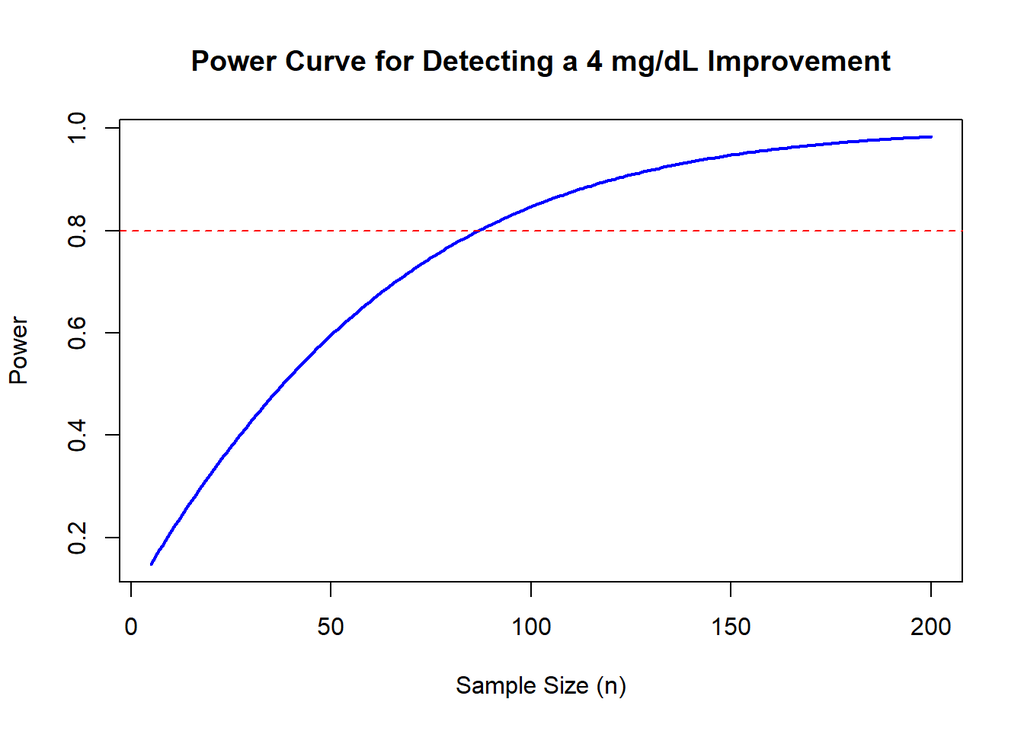

```r
# Parameters
sigma <- 15
alpha <- 0.05
mu0   <- 25
mu1   <- 29

# Critical z-value for right-tailed test
z_alpha <- qnorm(1 - alpha)

# Power function for a one-sample z-test
power_function <- function(n)
# power_function: function with one argument
# n: sample size
{
# this bracket begins the definition of the function
SE <- sigma / sqrt(n)
# SE: calculate standard error for given sample size
xbar_crit <- mu0 + z_alpha * SE
# xbar_crit: minimum value for which we can reject the null hypothesis
z_crit <- (xbar_crit - mu1) / SE
# z_crit: z-score associated with xbar_crit
power <- 1 - pnorm(z_crit)
# power: P(Xbar > xbar_crit | true mean = mu1)
return(power)
}
# this bracket ends the definition of the function

# Range of sample sizes
n_values <- seq(5, 200, by = 1)

# Compute power for each n
power_values <- sapply(n_values, power_function)
# sapply() loops over n_values, plugs each n into power_function, and returns a vector of power values of the same length

# Plot the power curve
plot(n_values, power_values, type = "l", lwd = 2, col = "blue",
     xlab = "Sample Size (n)",
     ylab = "Power",
     main = "Power Curve for Detecting a 4 mg/dL Improvement")

abline(h = 0.80, col = "red", lty = 2)
```

```r
# target power line
```

**Conclusion**

The power curve displays how the probability of correctly rejecting the null hypothesis increases as the sample size grows for a one‑sample right‑tailed z‑test. As the plot shows, power rises smoothly with 𝑛 , crossing the 0.80 threshold at approximately n = 87, which matches the analytic sample‑size calculation.

**Note**: For each of the questions above, write a short summary of what you observed, justify why your analysis is valid, and interpret the results.